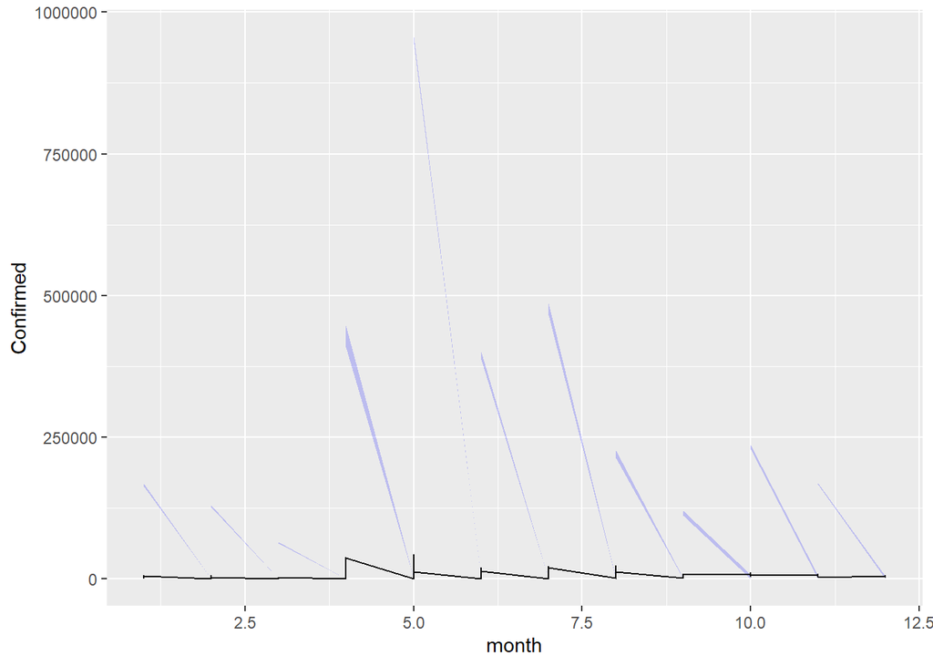

```r
##line graph with points
ggplot(data, aes(x = month, y= Confirmed)) + geom_area(fill = "blue", alpha = .2) + geom_line()
```

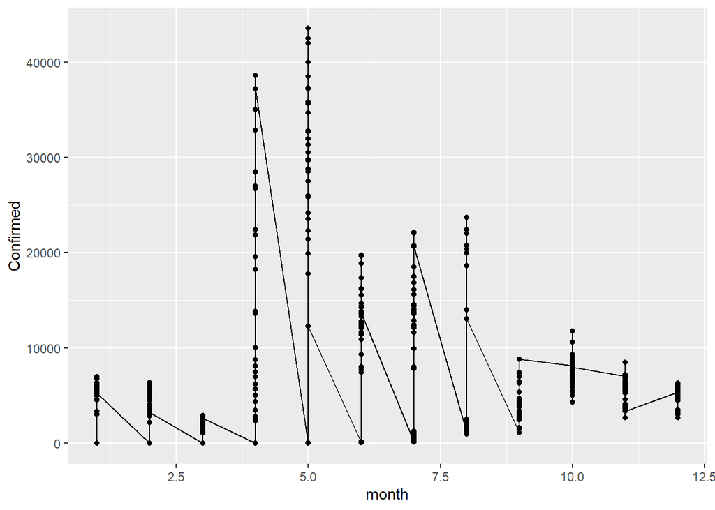

```r
ggplot(data, aes(x = month, y = Confirmed)) + geom_line() + geom_point()
```

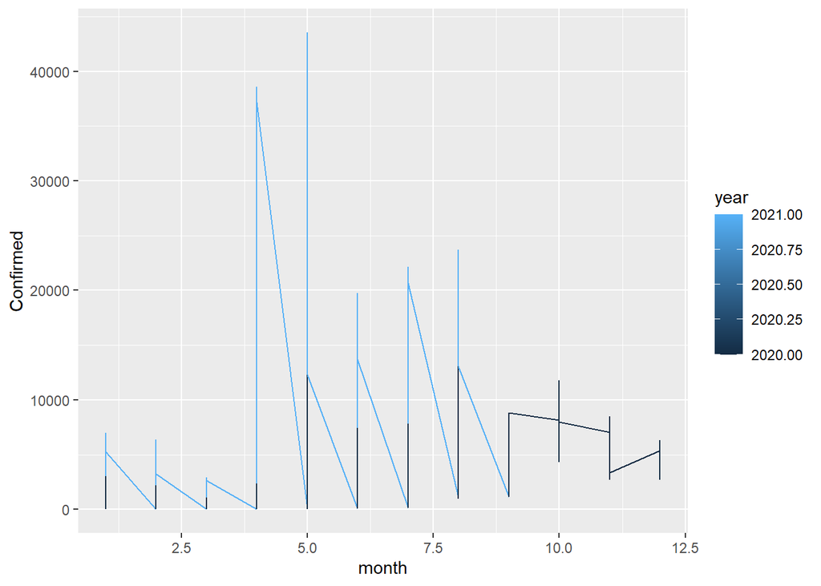

```r
##making a line graph with multiple lines(confirmed cases for same month but in 2 different year 2020 and 2021)
ggplot(data, aes(x = month, y = Confirmed, colour = year)) + geom_line()
```

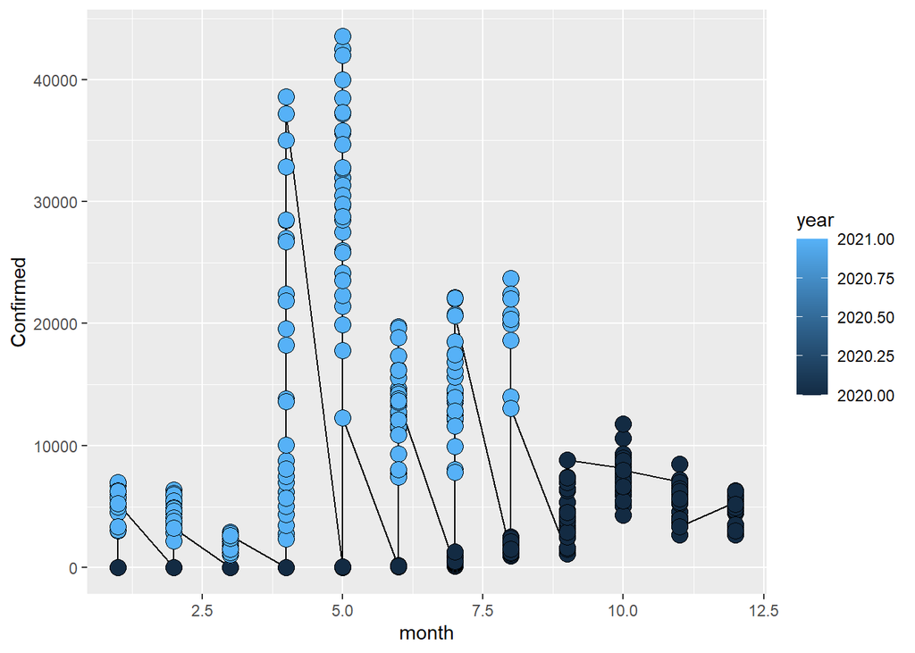

```r
##line graph with different colors
ggplot(data, aes(x = month, y = Confirmed, fill = year)) + geom_line() + geom_point(size = 4, shape = 21)
```

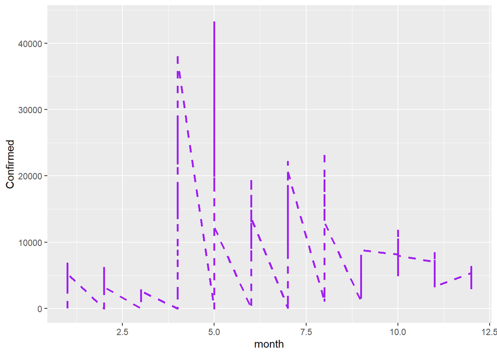

```r
##line graph with dashed line
ggplot(data, aes(x = month, y = Confirmed)) + geom_line(linetype = "dashed", size =1, colour = "purple")
```

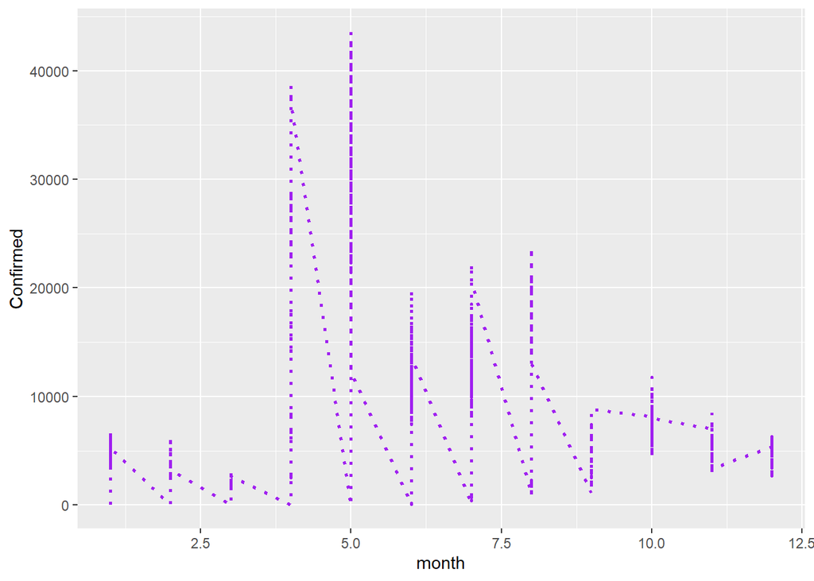

```r
##line graph with dotted line
ggplot(data, aes(x = month, y = Confirmed)) + geom_line(linetype = "dotted", size =1, colour = "purple")
```

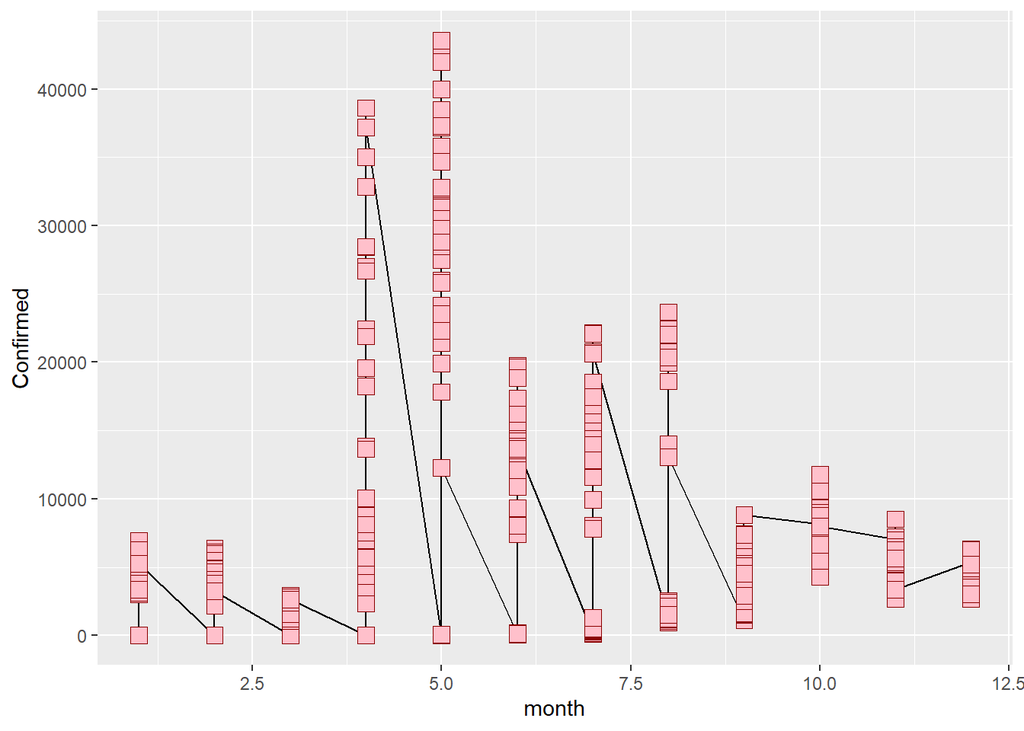

```r
##line graph with point custom size, shape, colour, fill
ggplot(data, aes(x = month, y = Confirmed)) + geom_line() + geom_point(size = 4, shape = 22, fill = "pink", colour = "darkred")
```

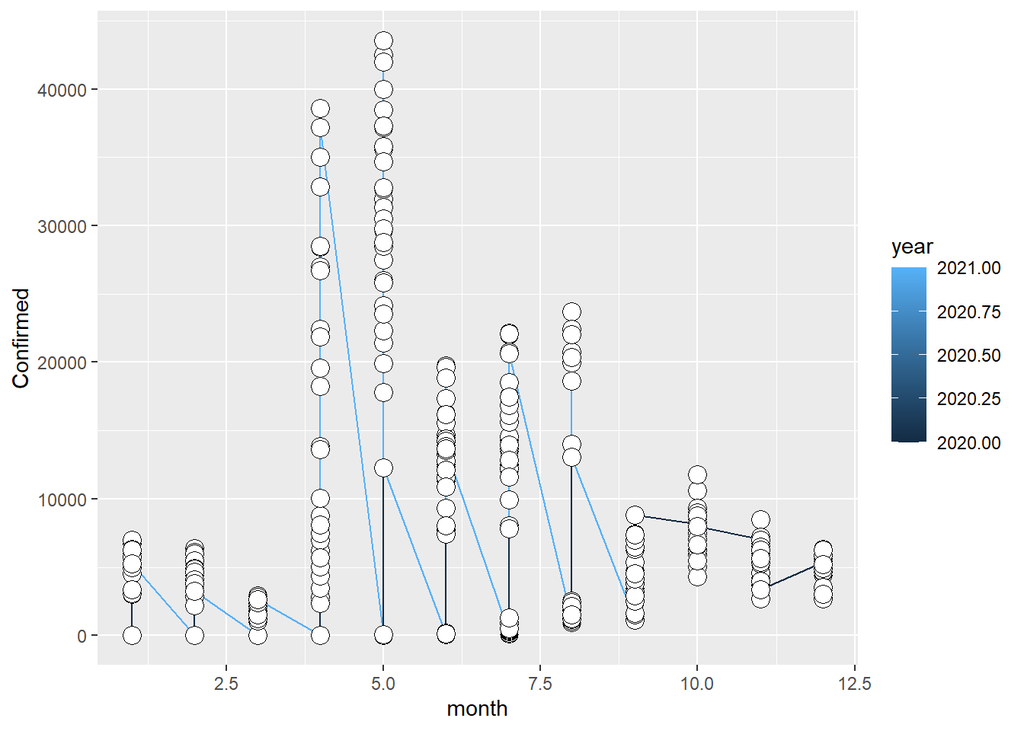

```r
##points with white fill
ggplot(data, aes(x = month, y = Confirmed)) + geom_line(aes(color = year)) + geom_point(size = 4, shape = 21 , fill = "white")
```

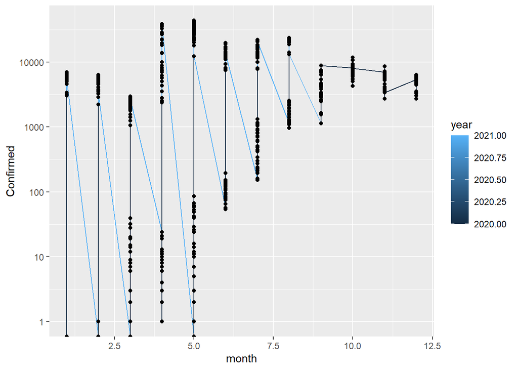

```r
ggplot(data, aes(x = month, y = Confirmed)) + geom_line(aes(color = year)) + geom_point() +scale_y_log10()
```

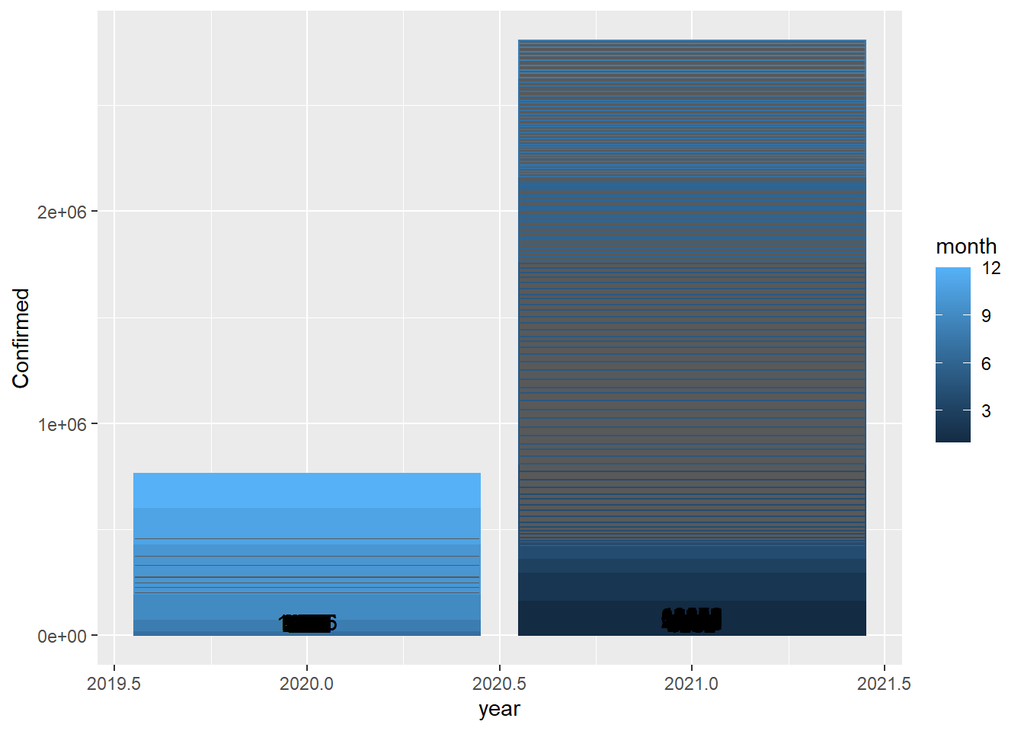

```r
ggplot(data, aes(x= year, y=Confirmed)) + geom_col(aes(color = month)) + geom_text(aes(label = Confirmed), vjust = -0.2)
```

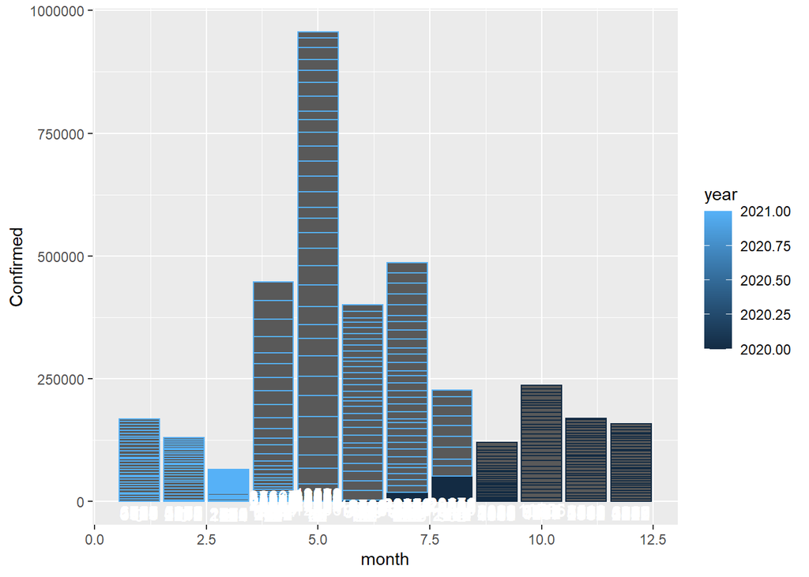

```r
ggplot(data, aes(x= month, y=Confirmed)) + geom_col(aes(color = year)) + geom_text(aes(label = Confirmed),vjust = 1.5, colour = "white")
```

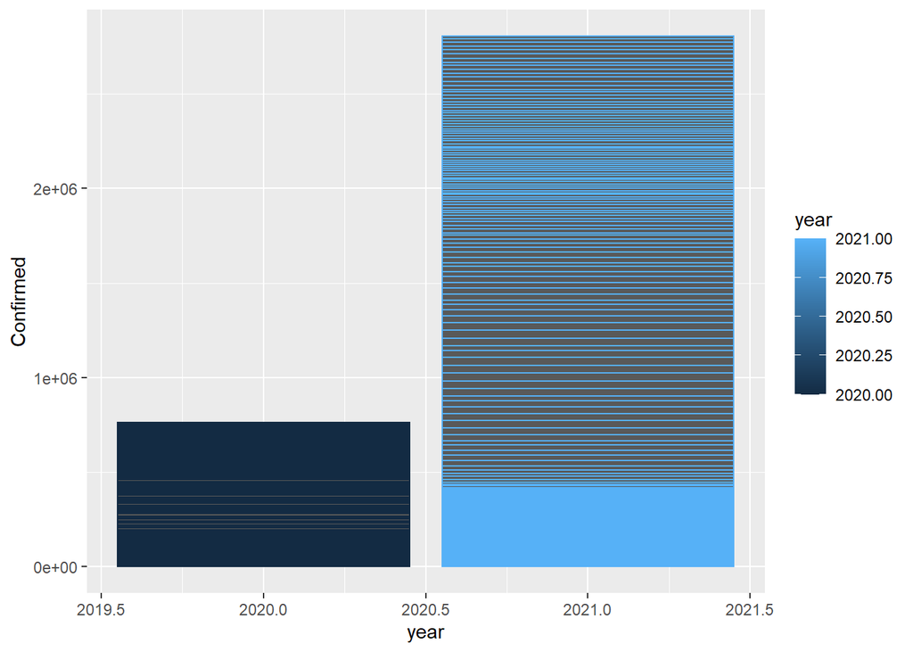

```r
ggplot(data , aes(x = year, y = Confirmed))+ geom_col(aes(color = year))
```

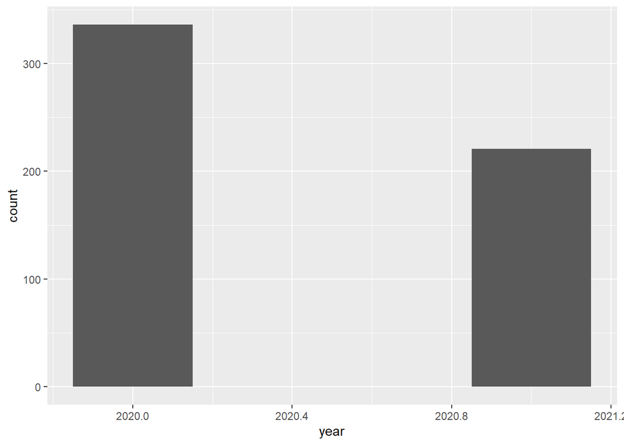

```r
ggplot(data, aes(x = year)) + geom_bar(width = 0.3, position = position_dodge(0.5))
```

plotting scatterplot

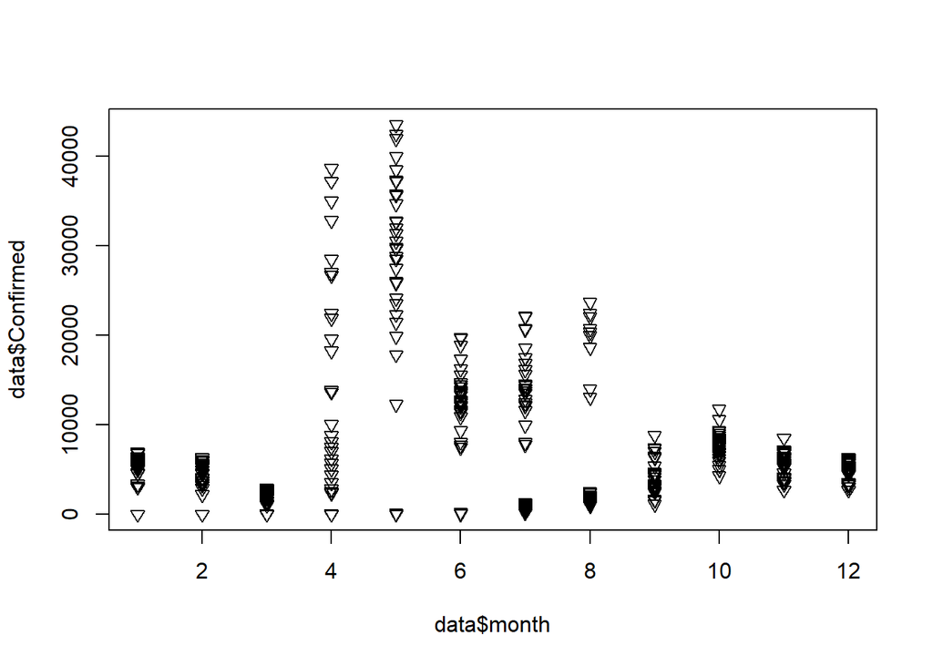

```r
##scatter plot
plot(data$month, data$Confirmed, pch = 25)
```

to get data of confirmed cases in the year 2020 of all the month dated as 01

```r
## assign each month to the same year and day for plotting
as.Date(paste0("2020-", data$month, "-01"), "%Y-%m-%d")
```

```
##   [1] "2020-01-01" "2020-02-01" "2020-02-01" "2020-02-01" "2020-02-01"
##   [6] "2020-02-01" "2020-02-01" "2020-02-01" "2020-02-01" "2020-02-01"
##  [11] "2020-02-01" "2020-02-01" "2020-02-01" "2020-02-01" "2020-02-01"
##  [16] "2020-02-01" "2020-02-01" "2020-02-01" "2020-02-01" "2020-02-01"
##  [21] "2020-02-01" "2020-02-01" "2020-02-01" "2020-02-01" "2020-02-01"
##  [26] "2020-02-01" "2020-02-01" "2020-02-01" "2020-02-01" "2020-02-01"
##  [31] "2020-03-01" "2020-03-01" "2020-03-01" "2020-03-01" "2020-03-01"
##  [36] "2020-03-01" "2020-03-01" "2020-03-01" "2020-03-01" "2020-03-01"
##  [41] "2020-03-01" "2020-03-01" "2020-03-01" "2020-03-01" "2020-03-01"
##  [46] "2020-03-01" "2020-03-01" "2020-03-01" "2020-03-01" "2020-03-01"
##  [51] "2020-03-01" "2020-03-01" "2020-03-01" "2020-03-01" "2020-03-01"
##  [56] "2020-03-01" "2020-03-01" "2020-03-01" "2020-03-01" "2020-03-01"
##  [61] "2020-03-01" "2020-04-01" "2020-04-01" "2020-04-01" "2020-04-01"
##  [66] "2020-04-01" "2020-04-01" "2020-04-01" "2020-04-01" "2020-04-01"
##  [71] "2020-04-01" "2020-04-01" "2020-04-01" "2020-04-01" "2020-04-01"
```

[output cut: 97 more lines]

plotting bargraph and using facet_wrap() function which partitions a plot into matrix of panels

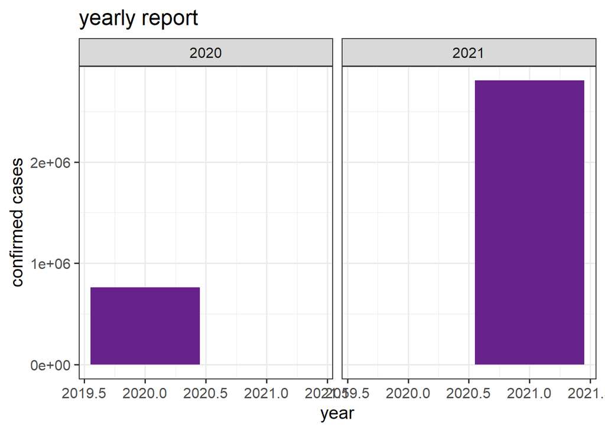

```r
##plots confirmed cases in whole year
data %>% ggplot(aes(x = year, y= Confirmed)) + geom_bar(stat = "identity", fill = "darkorchid4") + facet_wrap(~ year, ncol = 3) + labs(title = "yearly report", y = "confirmed cases", x= "year") + theme_bw(base_size = 15)
```

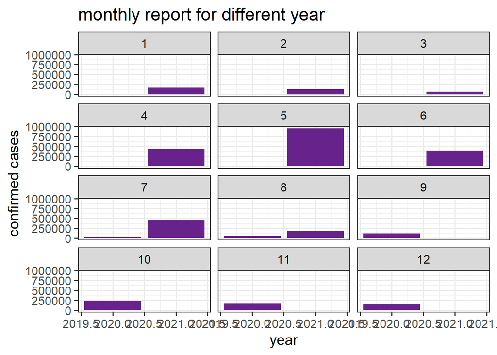

```r
##plots confirmed cases in all months of the year 2020 and 2021
data %>% ggplot(aes(x = year, y= Confirmed)) + geom_bar(stat = "identity", fill = "darkorchid4") + facet_wrap(~ month, ncol = 3) + labs(title = "monthly report for different year", y = "confirmed cases", x= "year") + theme_bw(base_size = 15)
```

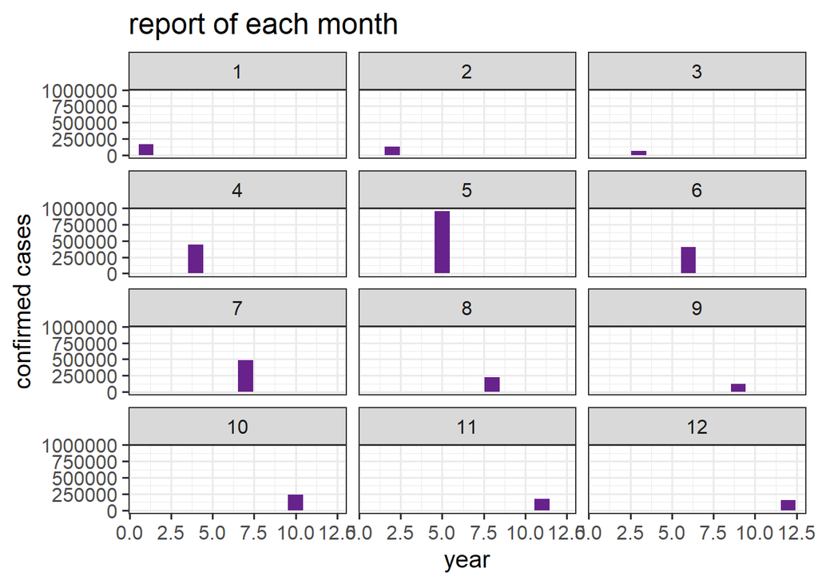

```r
##plots confirmed cases in all the months
data %>% ggplot(aes(x = month, y= Confirmed)) + geom_bar(stat = "identity", fill = "darkorchid4") + facet_wrap(~ month, ncol = 3) + labs(title = "report of each month", y = "confirmed cases", x= "year") + theme_bw(base_size = 15)
```

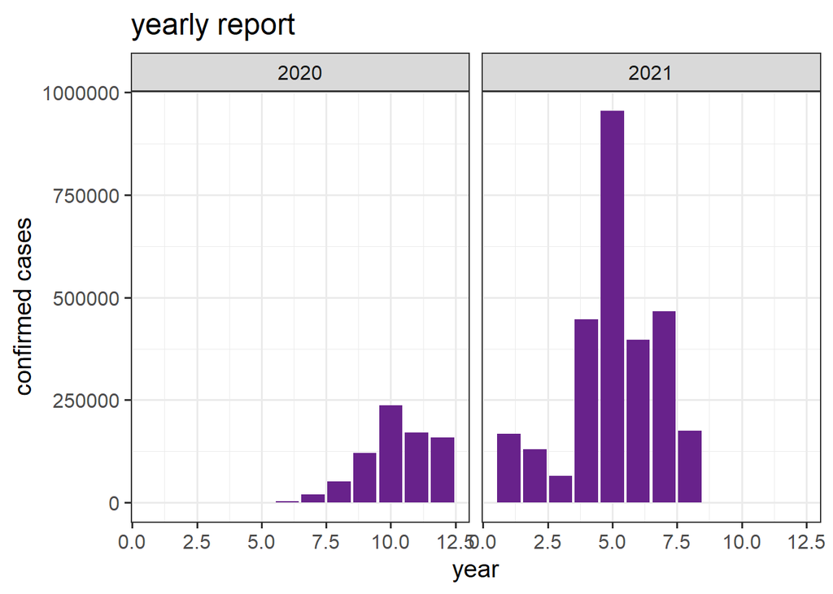

```r
data %>% ggplot(aes(x = month, y= Confirmed)) + geom_bar(stat = "identity", fill = "darkorchid4") + facet_wrap(~ year, ncol = 3) + labs(title = "yearly report", y = "confirmed cases", x= "year") + theme_bw(base_size = 15)
```

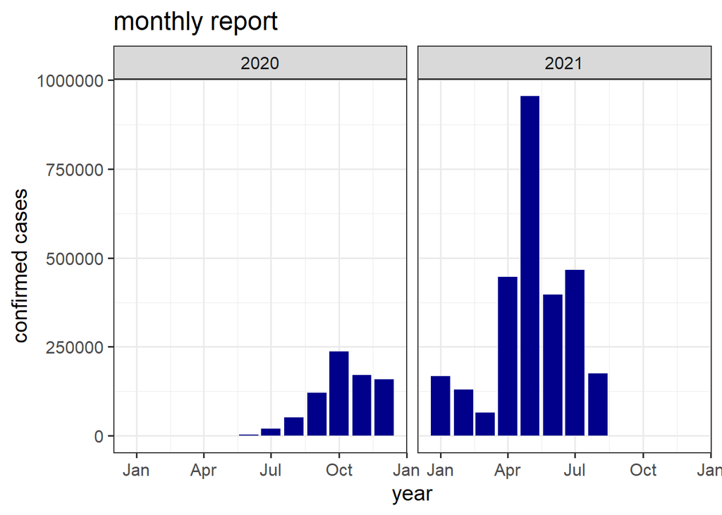

```r
data %>%  mutate(month2 = as.Date(paste0("2020-", month, "-01"), "%Y-%m-%d")) %>%  ggplot(aes(x = month2, y = Confirmed)) + geom_bar(stat = "identity", fill = "darkblue") + facet_wrap( ~ year, ncol = 3) + labs(title = "monthly report", subtite = "data plotted by year", y = "confirmed cases", x = "year") + theme_bw(base_size = 15) + scale_x_date(date_labels = "%b")
```

plotting point graph

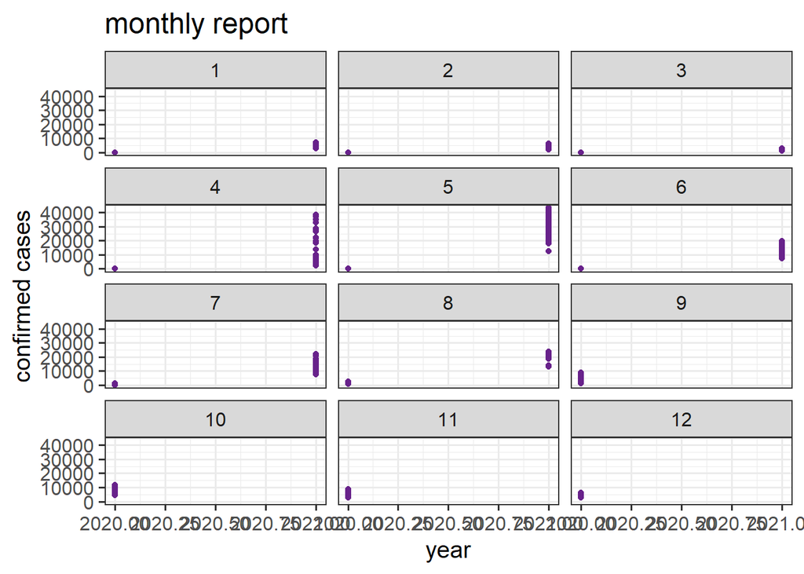

```r
##plot the data using ggplot2,pipes and facet_wrap
data  %>% ggplot(aes(x= year, y = Confirmed)) + geom_point(color = "darkorchid4") + facet_wrap( ~ month, ncol = 3) + labs(title = "monthly report", subtite = "use facets to plot by a variable - year", y = "confirmed cases", x = "year") + theme_bw(base_size = 15)
```

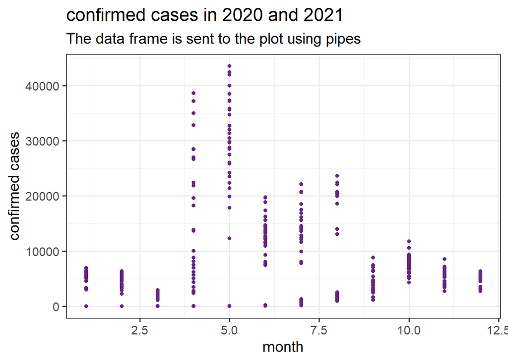

```r
##plot pointplot the data using ggplot2 and pipes
data %>% ggplot(aes(x = month, y = Confirmed)) + geom_point(color = "darkorchid4") + labs(title = "confirmed cases in 2020 and 2021", subtitle = "The data frame is sent to the plot using pipes", y = "confirmed cases", x = "month") + theme_bw(base_size = 15)
```

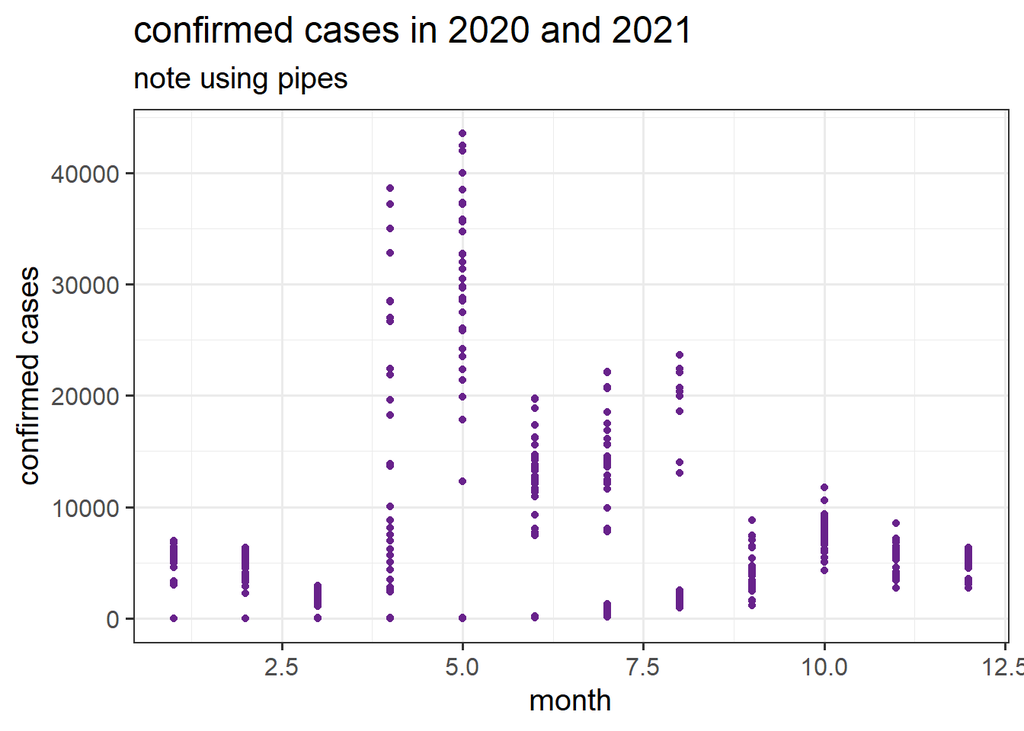

```r
ggplot(data, aes(x = month, y = Confirmed)) + geom_point(color = "darkorchid4") + labs(title = "confirmed cases in 2020 and 2021", subtitle = "note using pipes", y = "confirmed cases", x = "month") + theme_bw(base_size = 15)
```

plot of confirmed cases from 9th march to 20th march

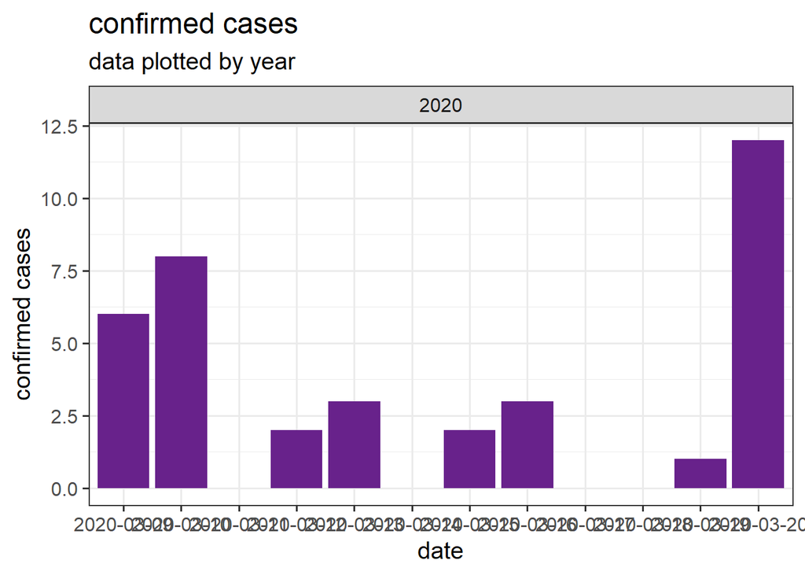

```r
##to plot bargraph of confirmed cases from 9th march to 20th march
newdata = data %>% filter(Date >= as.Date("2020-03-09") & Date <= as.Date("2020-03-20"))
newdata %>% ggplot(aes(x = Date, y = Confirmed)) + geom_bar(stat = "identity", fill = "darkorchid4") + facet_wrap( ~year, ncol = 3) + labs( title = "confirmed cases" , subtitle = "data plotted by year",y = "confirmed cases", x = "date") + theme_bw(base_size = 15)
```

add new column named “month2” which has dates of 2020year and date 01 , and then group the data by month2 and see the summary of confirmed

```r
##calculate the sum confirmed cases for each month in 2020 and date =01
data %>%  mutate(month2 = as.Date(paste0("2020-", month, "-01"), "%Y-%m-%d")) %>% group_by(month2) %>% summarise(sum_confirmed = sum(Confirmed))
```

```
## # A tibble: 12 x 2
##    month2     sum_confirmed
##    <date>             <dbl>
##  1 2020-01-01        168245
##  2 2020-02-01        130227
##  3 2020-03-01         65419
##  4 2020-04-01        446855
##  5 2020-05-01        956168
##  6 2020-06-01        400749
##  7 2020-07-01        485767
##  8 2020-08-01        226585
##  9 2020-09-01        120721
## 10 2020-10-01        236999
## 11 2020-11-01        169877
## 12 2020-12-01        157951
```

month and year is grouped and summarise() creates bew variable named “max_conf”

```r
## calculate the sum confirmed
data %>% group_by(month, year) %>% summarise(max_conf = sum(Confirmed))
```

```
## # A tibble: 20 x 3
## # Groups:   month [12]
##    month  year max_conf
##    <dbl> <dbl>    <dbl>
##  1     1  2020        0
##  2     1  2021   168245
##  3     2  2020        2
##  4     2  2021   130225
##  5     3  2020      238
##  6     3  2021    65181
##  7     4  2020      256
##  8     4  2021   446599
##  9     5  2020      772
## 10     5  2021   955396
## 11     6  2020     3173
## 12     6  2021   397576
## 13     7  2020    19171
## 14     7  2021   466596
## 15     8  2020    51772
## 16     8  2021   174813
## 17     9  2020   120721
## 18    10  2020   236999
## 19    11  2020   169877
## 20    12  2020   157951
```

with() function evaluates an R expression in an environment constructed based on a dataframe

```r
with(data, (data$Confirmed[data$year == "2020"]))
```

```
##   [1]     0     0     1     1     0     0     0     0     0     0     0     0
##  [13]     0     0     0     0     0     0     0     0     0     0     0     0
##  [25]     0     0     0     0     0     0     0     0     0     0     0     0
##  [37]     0     0     6     8     0     2     3     0     2     3     0     0
##  [49]     1    12    12    15    28    14     9    19    39     6    20    32
##  [61]     7    24    21     9    11     8    13     8     9    12     7    10
##  [73]     2     3     8     1     7     1     4     2     6    19    11    10
##  [85]     3     7    11    13     4    10     2     0     2     0     0     3
##  [97]     0     0     1     2     7     7     5    10    26    16    11    14
## [109]    29    12    24    24    42    62    53    49    67    40    85    62
## [121]    58    61    57    86    82    94   111   108   107    91    91    65
## [133]    83    78    85    54    82    79    75    97   118   127   133   138
## [145]   141   152   123   150   195   118   122   131   151   160   211   240
## [157]   225   193   272   301   339   416   488   435   449   608   623   722
## [169]   791   593   821   794   720  1038  1078   885  1103   927   702  1167
## [181]   903   506  1310  1129  1169   962  1083  1195  1298  1251  1420  1211
## [193]  1184  1417  1212  1564  1569  1608  1530  1725  1758  2333  1968  1983
## [205]  2172  1908  1242  2375  2476  2406  2543  2397  2154  1530  1140  1547
## [217]  1553  2479  2655  3082  1648  3026  3402  3349  2988  2885  3139  2540
## [229]  3215  3830  4351  4167  4644  4696  2910  4125  5376  6324  6477  7006
## [241]  7445  4538  7354  8830  8135  9258  7834  8553  5042  7871 10606  5445
## [253]  9250 11755  9347  5930  8764  6244  7789  7283  9016  7631  5022  6591
## [265]  8369  7482  8511  8253  6843  4287  5457  8790  7020  6638  7983  7025
## [277]  4138  6862  8516  6820  7002  7201  5440  3593  6010  7007  5537  5804
## [289]  6357  4581  2710  5792  6419  5722  6028  5772  5254  3757  5420  6491
## [301]  5378  3966  6250  5643  3382  5375  6316  5376  5718  5848  4777  3272
## [313]  5032  4875  4470  4642  5949  4698  2707  5218  6185  4969  5456  6293
## [325]  5711  3423  6049  6169  5177  5397  3527  4905  3047  5887  6268  5215
```

pairs() function is used to return a plot matrix, consisting of scatter plots

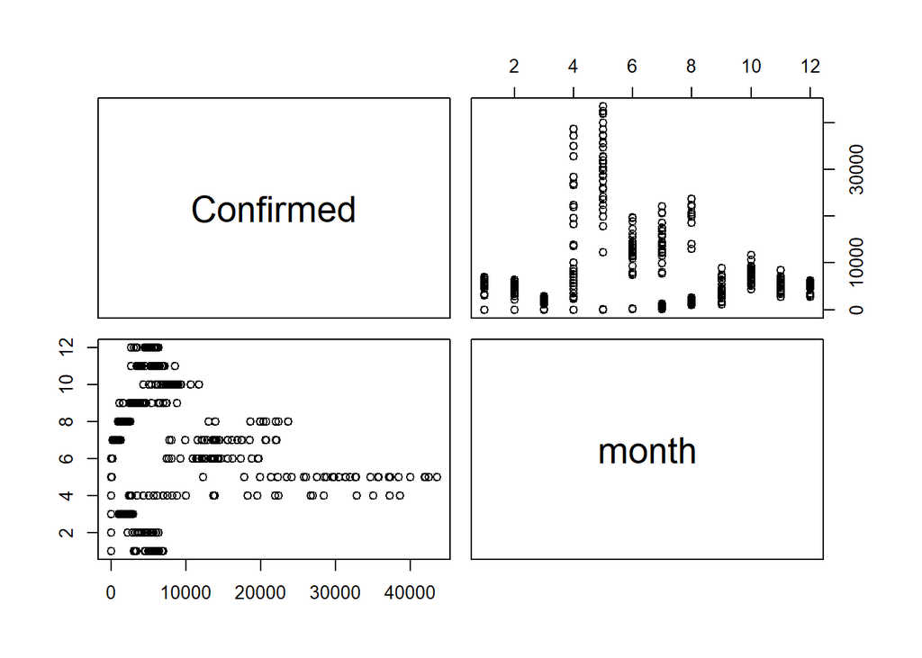

```r
pairs(~ Confirmed + month , data = data)
```

dotchart() function ismused to create a dot chart of the specified data.A dot chart is defined as a plot which is used to draw a cleveland dot plot.

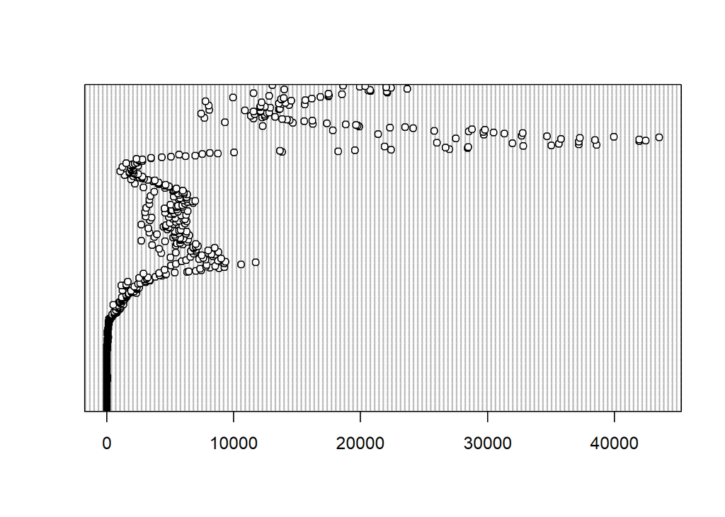

```r
dotchart(data$Confirmed)
```

aov() function is used to do ANOVA in R . na.omit() function removes all incomplete cases of a dataobject

```r
data.aov = na.omit(data$Confirmed)
data.aov
```

```
##   [1]     0     0     1     1     0     0     0     0     0     0     0     0
##  [13]     0     0     0     0     0     0     0     0     0     0     0     0
##  [25]     0     0     0     0     0     0     0     0     0     0     0     0
##  [37]     0     0     6     8     0     2     3     0     2     3     0     0
##  [49]     1    12    12    15    28    14     9    19    39     6    20    32
##  [61]     7    24    21     9    11     8    13     8     9    12     7    10
##  [73]     2     3     8     1     7     1     4     2     6    19    11    10
##  [85]     3     7    11    13     4    10     2     0     2     0     0     3
##  [97]     0     0     1     2     7     7     5    10    26    16    11    14
## [109]    29    12    24    24    42    62    53    49    67    40    85    62
## [121]    58    61    57    86    82    94   111   108   107    91    91    65
## [133]    83    78    85    54    82    79    75    97   118   127   133   138
## [145]   141   152   123   150   195   118   122   131   151   160   211   240
## [157]   225   193   272   301   339   416   488   435   449   608   623   722
## [169]   791   593   821   794   720  1038  1078   885  1103   927   702  1167
```

[output cut: 32 more lines]

```r
summary(data.aov)
```

```
##    Min. 1st Qu.  Median    Mean 3rd Qu.    Max.
##       0     111    3423    6401    7449   43529
```

frequency polygon geom_freqpoly displays the counts with line , binwidth= the width of the bins

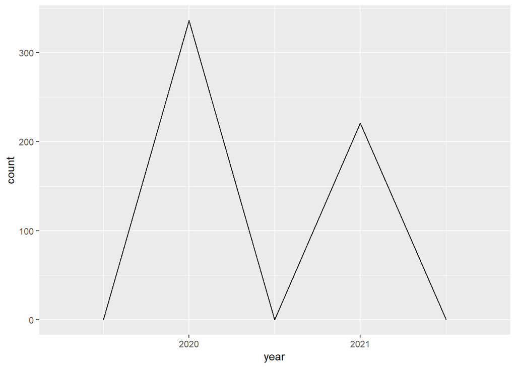

```r
data %>% ggplot(aes(year)) + geom_freqpoly(binwidth = 0.5)
```

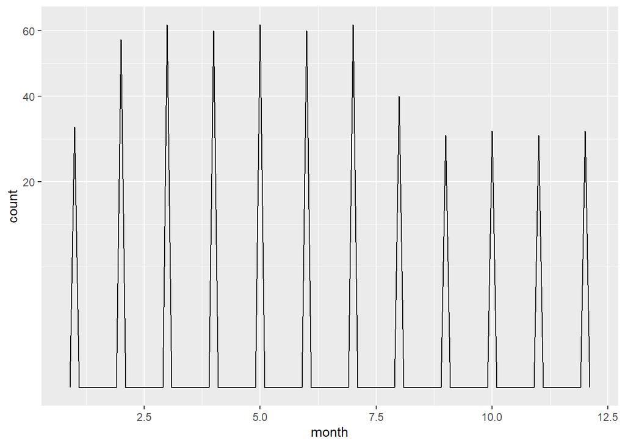

```r
data %>% ggplot(aes(month)) + geom_freqpoly(binwidth = 0.1) + scale_y_sqrt()
```

factor() is used to categorize and store the data having limited number of differnt values. it stores data as a vector of integer valuesre

```r
factor(data$Confirmed)
```

```
##   [1] 0     0     1     1     0     0     0     0     0     0     0     0
##  [13] 0     0     0     0     0     0     0     0     0     0     0     0
##  [25] 0     0     0     0     0     0     0     0     0     0     0     0
##  [37] 0     0     6     8     0     2     3     0     2     3     0     0
##  [49] 1     12    12    15    28    14    9     19    39    6     20    32
##  [61] 7     24    21    9     11    8     13    8     9     12    7     10
##  [73] 2     3     8     1     7     1     4     2     6     19    11    10
##  [85] 3     7     11    13    4     10    2     0     2     0     0     3
##  [97] 0     0     1     2     7     7     5     10    26    16    11    14
## [109] 29    12    24    24    42    62    53    49    67    40    85    62
## [121] 58    61    57    86    82    94    111   108   107   91    91    65
## [133] 83    78    85    54    82    79    75    97    118   127   133   138
## [145] 141   152   123   150   195   118   122   131   151   160   211   240
## [157] 225   193   272   301   339   416   488   435   449   608   623   722
## [169] 791   593   821   794   720   1038  1078  885   1103  927   702   1167
```

[output cut: 33 more lines]

```r
factor(data$year)
```

```
##   [1] 2020 2020 2020 2020 2020 2020 2020 2020 2020 2020 2020 2020 2020 2020 2020
##  [16] 2020 2020 2020 2020 2020 2020 2020 2020 2020 2020 2020 2020 2020 2020 2020
##  [31] 2020 2020 2020 2020 2020 2020 2020 2020 2020 2020 2020 2020 2020 2020 2020
##  [46] 2020 2020 2020 2020 2020 2020 2020 2020 2020 2020 2020 2020 2020 2020 2020
##  [61] 2020 2020 2020 2020 2020 2020 2020 2020 2020 2020 2020 2020 2020 2020 2020
##  [76] 2020 2020 2020 2020 2020 2020 2020 2020 2020 2020 2020 2020 2020 2020 2020
##  [91] 2020 2020 2020 2020 2020 2020 2020 2020 2020 2020 2020 2020 2020 2020 2020
## [106] 2020 2020 2020 2020 2020 2020 2020 2020 2020 2020 2020 2020 2020 2020 2020
## [121] 2020 2020 2020 2020 2020 2020 2020 2020 2020 2020 2020 2020 2020 2020 2020
## [136] 2020 2020 2020 2020 2020 2020 2020 2020 2020 2020 2020 2020 2020 2020 2020
## [151] 2020 2020 2020 2020 2020 2020 2020 2020 2020 2020 2020 2020 2020 2020 2020
## [166] 2020 2020 2020 2020 2020 2020 2020 2020 2020 2020 2020 2020 2020 2020 2020
## [181] 2020 2020 2020 2020 2020 2020 2020 2020 2020 2020 2020 2020 2020 2020 2020
## [196] 2020 2020 2020 2020 2020 2020 2020 2020 2020 2020 2020 2020 2020 2020 2020
## [211] 2020 2020 2020 2020 2020 2020 2020 2020 2020 2020 2020 2020 2020 2020 2020
```

[output cut: 24 more lines]

```r
factor(data$Date)
```

```
##   [1] 2020-01-31 2020-02-01 2020-02-02 2020-02-03 2020-02-04 2020-02-05
##   [7] 2020-02-06 2020-02-07 2020-02-08 2020-02-09 2020-02-10 2020-02-11
##  [13] 2020-02-12 2020-02-13 2020-02-14 2020-02-15 2020-02-16 2020-02-17
##  [19] 2020-02-18 2020-02-19 2020-02-20 2020-02-21 2020-02-22 2020-02-23
##  [25] 2020-02-24 2020-02-25 2020-02-26 2020-02-27 2020-02-28 2020-02-29
##  [31] 2020-03-01 2020-03-02 2020-03-03 2020-03-04 2020-03-05 2020-03-06
##  [37] 2020-03-07 2020-03-08 2020-03-09 2020-03-10 2020-03-11 2020-03-12
##  [43] 2020-03-13 2020-03-14 2020-03-15 2020-03-16 2020-03-17 2020-03-18
##  [49] 2020-03-19 2020-03-20 2020-03-21 2020-03-22 2020-03-23 2020-03-24
##  [55] 2020-03-25 2020-03-26 2020-03-27 2020-03-28 2020-03-29 2020-03-30
##  [61] 2020-03-31 2020-04-01 2020-04-02 2020-04-03 2020-04-04 2020-04-05
##  [67] 2020-04-06 2020-04-07 2020-04-08 2020-04-09 2020-04-10 2020-04-11
##  [73] 2020-04-12 2020-04-13 2020-04-14 2020-04-15 2020-04-16 2020-04-17
##  [79] 2020-04-18 2020-04-19 2020-04-20 2020-04-21 2020-04-22 2020-04-23
##  [85] 2020-04-24 2020-04-25 2020-04-26 2020-04-27 2020-04-28 2020-04-29
```

[output cut: 79 more lines]

```r
factor(data$month)
```

```
##   [1] 1  2  2  2  2  2  2  2  2  2  2  2  2  2  2  2  2  2  2  2  2  2  2  2  2
##  [26] 2  2  2  2  2  3  3  3  3  3  3  3  3  3  3  3  3  3  3  3  3  3  3  3  3
##  [51] 3  3  3  3  3  3  3  3  3  3  3  4  4  4  4  4  4  4  4  4  4  4  4  4  4
##  [76] 4  4  4  4  4  4  4  4  4  4  4  4  4  4  4  4  5  5  5  5  5  5  5  5  5
## [101] 5  5  5  5  5  5  5  5  5  5  5  5  5  5  5  5  5  5  5  5  5  5  6  6  6
## [126] 6  6  6  6  6  6  6  6  6  6  6  6  6  6  6  6  6  6  6  6  6  6  6  6  6
## [151] 6  6  7  7  7  7  7  7  7  7  7  7  7  7  7  7  7  7  7  7  7  7  7  7  7
## [176] 7  7  7  7  7  7  7  7  8  8  8  8  8  8  8  8  8  8  8  8  8  8  8  8  8
## [201] 8  8  8  8  8  8  8  8  8  8  8  8  8  8  9  9  9  9  9  9  9  9  9  9  9
## [226] 9  9  9  9  9  9  9  9  9  9  9  9  9  9  9  9  9  9  9  10 10 10 10 10 10
## [251] 10 10 10 10 10 10 10 10 10 10 10 10 10 10 10 10 10 10 10 10 10 10 10 10 10
## [276] 11 11 11 11 11 11 11 11 11 11 11 11 11 11 11 11 11 11 11 11 11 11 11 11 11
## [301] 11 11 11 11 11 12 12 12 12 12 12 12 12 12 12 12 12 12 12 12 12 12 12 12 12
## [326] 12 12 12 12 12 12 12 12 12 12 12 1  1  1  1  1  1  1  1  1  1  1  1  1  1
## [351] 1  1  1  1  1  1  1  1  1  1  1  1  1  1  1  1  1  2  2  2  2  2  2  2  2
## [376] 2  2  2  2  2  2  2  2  2  2  2  2  2  2  2  2  2  2  2  2  3  3  3  3  3
## [401] 3  3  3  3  3  3  3  3  3  3  3  3  3  3  3  3  3  3  3  3  3  3  3  3  3
## [426] 3  4  4  4  4  4  4  4  4  4  4  4  4  4  4  4  4  4  4  4  4  4  4  4  4
## [451] 4  4  4  4  4  4  5  5  5  5  5  5  5  5  5  5  5  5  5  5  5  5  5  5  5
## [476] 5  5  5  5  5  5  5  5  5  5  5  5  6  6  6  6  6  6  6  6  6  6  6  6  6
## [501] 6  6  6  6  6  6  6  6  6  6  6  6  6  6  6  6  6  7  7  7  7  7  7  7  7
## [526] 7  7  7  7  7  7  7  7  7  7  7  7  7  7  7  7  7  7  7  7  7  7  7  8  8
## [551] 8  8  8  8  8  8  8
## Levels: 1 2 3 4 5 6 7 8 9 10 11 12
```

rep() replicates the element of lists and vector

```r
head(rep(data))
```

```
## $Date
##   [1] "2020-01-31" "2020-02-01" "2020-02-02" "2020-02-03" "2020-02-04"
##   [6] "2020-02-05" "2020-02-06" "2020-02-07" "2020-02-08" "2020-02-09"
##  [11] "2020-02-10" "2020-02-11" "2020-02-12" "2020-02-13" "2020-02-14"
##  [16] "2020-02-15" "2020-02-16" "2020-02-17" "2020-02-18" "2020-02-19"
##  [21] "2020-02-20" "2020-02-21" "2020-02-22" "2020-02-23" "2020-02-24"
##  [26] "2020-02-25" "2020-02-26" "2020-02-27" "2020-02-28" "2020-02-29"
##  [31] "2020-03-01" "2020-03-02" "2020-03-03" "2020-03-04" "2020-03-05"
##  [36] "2020-03-06" "2020-03-07" "2020-03-08" "2020-03-09" "2020-03-10"
##  [41] "2020-03-11" "2020-03-12" "2020-03-13" "2020-03-14" "2020-03-15"
##  [46] "2020-03-16" "2020-03-17" "2020-03-18" "2020-03-19" "2020-03-20"
##  [51] "2020-03-21" "2020-03-22" "2020-03-23" "2020-03-24" "2020-03-25"
##  [56] "2020-03-26" "2020-03-27" "2020-03-28" "2020-03-29" "2020-03-30"
##  [61] "2020-03-31" "2020-04-01" "2020-04-02" "2020-04-03" "2020-04-04"
##  [66] "2020-04-05" "2020-04-06" "2020-04-07" "2020-04-08" "2020-04-09"
```

[output cut: 212 more lines]

```r
head(rep(data$Confirmed))
```

```
## [1] 0 0 1 1 0 0
```

col() function gets the column number of a matrix

```r
col(data, as.factor = FALSE)
```

```
##        [,1] [,2] [,3] [,4]
##   [1,]    1    2    3    4
##   [2,]    1    2    3    4
##   [3,]    1    2    3    4
##   [4,]    1    2    3    4
##   [5,]    1    2    3    4
##   [6,]    1    2    3    4
##   [7,]    1    2    3    4
##   [8,]    1    2    3    4
##   [9,]    1    2    3    4
##  [10,]    1    2    3    4
##  [11,]    1    2    3    4
##  [12,]    1    2    3    4
##  [13,]    1    2    3    4
##  [14,]    1    2    3    4
```

[output cut: 543 more lines]

```r
y <- matrix(rep(1:9),3,3)
col(y)
```

```
##      [,1] [,2] [,3]
## [1,]    1    2    3
## [2,]    1    2    3
## [3,]    1    2    3
```

to get all the row values of 2nd and 3rd column i.e., confirmed and year

```r
x = data[ , 2:3]
head(x)
```

```
## # A tibble: 6 x 2
## # Groups:   year [1]
##   Confirmed  year
##       <dbl> <dbl>
## 1         0  2020
## 2         0  2020
## 3         1  2020
## 4         1  2020
## 5         0  2020
## 6         0  2020
```

colMeans() function gives mean value of the columns in the dataset rowMeans() function gives mean value of the rows in the dataset colSums() and rowSums() gives the sums of matrix or array columns

```r
colMeans(x)
```

```
## Confirmed      year
##  6401.370  2020.397
```

```r
rowMeans(x)
```

```
##   [1]  1010.0  1010.0  1010.5  1010.5  1010.0  1010.0  1010.0  1010.0  1010.0
##  [10]  1010.0  1010.0  1010.0  1010.0  1010.0  1010.0  1010.0  1010.0  1010.0
##  [19]  1010.0  1010.0  1010.0  1010.0  1010.0  1010.0  1010.0  1010.0  1010.0
##  [28]  1010.0  1010.0  1010.0  1010.0  1010.0  1010.0  1010.0  1010.0  1010.0
##  [37]  1010.0  1010.0  1013.0  1014.0  1010.0  1011.0  1011.5  1010.0  1011.0
##  [46]  1011.5  1010.0  1010.0  1010.5  1016.0  1016.0  1017.5  1024.0  1017.0
##  [55]  1014.5  1019.5  1029.5  1013.0  1020.0  1026.0  1013.5  1022.0  1020.5
##  [64]  1014.5  1015.5  1014.0  1016.5  1014.0  1014.5  1016.0  1013.5  1015.0
##  [73]  1011.0  1011.5  1014.0  1010.5  1013.5  1010.5  1012.0  1011.0  1013.0
##  [82]  1019.5  1015.5  1015.0  1011.5  1013.5  1015.5  1016.5  1012.0  1015.0
##  [91]  1011.0  1010.0  1011.0  1010.0  1010.0  1011.5  1010.0  1010.0  1010.5
## [100]  1011.0  1013.5  1013.5  1012.5  1015.0  1023.0  1018.0  1015.5  1017.0
## [109]  1024.5  1016.0  1022.0  1022.0  1031.0  1041.0  1036.5  1034.5  1043.5
## [118]  1030.0  1052.5  1041.0  1039.0  1040.5  1038.5  1053.0  1051.0  1057.0
## [127]  1065.5  1064.0  1063.5  1055.5  1055.5  1042.5  1051.5  1049.0  1052.5
```

[output cut: 47 more lines]

```r
colSums(x)
```

```
## Confirmed      year
##   3565563   1125361
```

```r
rowSums(x)
```

```
##   [1]  2020  2020  2021  2021  2020  2020  2020  2020  2020  2020  2020  2020
##  [13]  2020  2020  2020  2020  2020  2020  2020  2020  2020  2020  2020  2020
##  [25]  2020  2020  2020  2020  2020  2020  2020  2020  2020  2020  2020  2020
##  [37]  2020  2020  2026  2028  2020  2022  2023  2020  2022  2023  2020  2020
##  [49]  2021  2032  2032  2035  2048  2034  2029  2039  2059  2026  2040  2052
##  [61]  2027  2044  2041  2029  2031  2028  2033  2028  2029  2032  2027  2030
##  [73]  2022  2023  2028  2021  2027  2021  2024  2022  2026  2039  2031  2030
##  [85]  2023  2027  2031  2033  2024  2030  2022  2020  2022  2020  2020  2023
##  [97]  2020  2020  2021  2022  2027  2027  2025  2030  2046  2036  2031  2034
## [109]  2049  2032  2044  2044  2062  2082  2073  2069  2087  2060  2105  2082
## [121]  2078  2081  2077  2106  2102  2114  2131  2128  2127  2111  2111  2085
## [133]  2103  2098  2105  2074  2102  2099  2095  2117  2138  2147  2153  2158
## [145]  2161  2172  2143  2170  2215  2138  2142  2151  2171  2180  2231  2260
## [157]  2245  2213  2292  2321  2359  2436  2508  2455  2469  2628  2643  2742
## [169]  2811  2613  2841  2814  2740  3058  3098  2905  3123  2947  2722  3187
```

[output cut: 32 more lines]

apply() function used to apply a function across an array, matrix or dataframe

```r
##vmean on columns
apply(data[ , 2:3], 2 , mean)
```

```
## Confirmed      year
##  6401.370  2020.397
```

```r
##mean on rows
apply(data[ , 2:3], 1 , mean)
```

```
##   [1]  1010.0  1010.0  1010.5  1010.5  1010.0  1010.0  1010.0  1010.0  1010.0
##  [10]  1010.0  1010.0  1010.0  1010.0  1010.0  1010.0  1010.0  1010.0  1010.0
##  [19]  1010.0  1010.0  1010.0  1010.0  1010.0  1010.0  1010.0  1010.0  1010.0
##  [28]  1010.0  1010.0  1010.0  1010.0  1010.0  1010.0  1010.0  1010.0  1010.0
##  [37]  1010.0  1010.0  1013.0  1014.0  1010.0  1011.0  1011.5  1010.0  1011.0
##  [46]  1011.5  1010.0  1010.0  1010.5  1016.0  1016.0  1017.5  1024.0  1017.0
##  [55]  1014.5  1019.5  1029.5  1013.0  1020.0  1026.0  1013.5  1022.0  1020.5
##  [64]  1014.5  1015.5  1014.0  1016.5  1014.0  1014.5  1016.0  1013.5  1015.0
##  [73]  1011.0  1011.5  1014.0  1010.5  1013.5  1010.5  1012.0  1011.0  1013.0
##  [82]  1019.5  1015.5  1015.0  1011.5  1013.5  1015.5  1016.5  1012.0  1015.0
##  [91]  1011.0  1010.0  1011.0  1010.0  1010.0  1011.5  1010.0  1010.0  1010.5
## [100]  1011.0  1013.5  1013.5  1012.5  1015.0  1023.0  1018.0  1015.5  1017.0
## [109]  1024.5  1016.0  1022.0  1022.0  1031.0  1041.0  1036.5  1034.5  1043.5
## [118]  1030.0  1052.5  1041.0  1039.0  1040.5  1038.5  1053.0  1051.0  1057.0
## [127]  1065.5  1064.0  1063.5  1055.5  1055.5  1042.5  1051.5  1049.0  1052.5
```

[output cut: 47 more lines]

```r
##median
apply(data[ , 2:3], 2 , median)
```

```
## Confirmed      year
##      3423      2020
```

```r
##variance
apply(data[ , 2:3], 2 , var)
```

```
##    Confirmed         year
## 7.546279e+07 2.397737e-01
```

tapply() to summarize using a grouping variable

```r
tapply(data$Confirmed, data$year, FUN = mean)
```

```
##      2020      2021
##  2264.679 12690.638
```

```r
tapply(data$Confirmed, data$year, FUN = var)
```

```
##      2020      2021
##   8130155 112465331
```

```r
tapply(data$Confirmed, data$year, FUN = sd)
```

```
##      2020      2021
##  2851.343 10604.967
```

```r
tapply(data$Confirmed, data$year, FUN = median)
```

```
##   2020   2021
##  615.5 9313.0
```

na.omit() function removes all incomplete cases of a dataobject

```r
head(na.omit(data))
```

```
## # A tibble: 6 x 4
## # Groups:   year, month [2]
##   Date       Confirmed  year month
##   <chr>          <dbl> <dbl> <dbl>
## 1 2020-01-31         0  2020     1
## 2 2020-02-01         0  2020     2
## 3 2020-02-02         1  2020     2
## 4 2020-02-03         1  2020     2
## 5 2020-02-04         0  2020     2
## 6 2020-02-05         0  2020     2
```

object( ) and ls() functions both does same operation object() returns a list of objectnames ls() function is used to list the names of all the objects that are present in working library

```r
objects(data)
```

```
## [1] "Confirmed" "Date"      "month"     "year"
```

```r
ls(data)
```

```
## [1] "Confirmed" "Date"      "month"     "year"
```

Simple linear Regression lm() function can be used to determine the beta coefficients of liner model

```r
data_regr = lm(month ~ Confirmed, data)
data_regr
```

```
##
## Call:
## lm(formula = month ~ Confirmed, data = data)
##
## Coefficients:
## (Intercept)    Confirmed
##   5.725e+00    2.497e-05
```

```r
##summary
summary(data_regr)
```

```
##
## Call:
## lm(formula = month ~ Confirmed, data = data)
##
## Residuals:
##     Min      1Q  Median      3Q     Max
## -4.8990 -2.7253 -0.1299  2.2346  6.2071
##
## Coefficients:
##              Estimate Std. Error t value Pr(>|t|)
## (Intercept) 5.725e+00  1.641e-01  34.886   <2e-16 ***
## Confirmed   2.497e-05  1.522e-05   1.641    0.101
## ---
## Signif. codes:  0 '***' 0.001 '**' 0.01 '*' 0.05 '.' 0.1 ' ' 1
##
## Residual standard error: 3.117 on 555 degrees of freedom
## Multiple R-squared:  0.004827,   Adjusted R-squared:  0.003034
## F-statistic: 2.692 on 1 and 555 DF,  p-value: 0.1014
```

```r
##confidence interval
confint(data_regr)
```

```
##                     2.5 %       97.5 %
## (Intercept)  5.402908e+00 6.0476255560
## Confirmed   -4.922613e-06 0.0000548594
```

```r
cor.test( ~ data$Confirmed + data$month)
```

```
##
##  Pearson's product-moment correlation
##
## data:  data$Confirmed and data$month
## t = 1.6408, df = 555, p-value = 0.1014
## alternative hypothesis: true correlation is not equal to 0
## 95 percent confidence interval:
##  -0.01367964  0.15168170
## sample estimates:
##        cor
## 0.06947828
```

```r
coef(data_regr)
```

```
##  (Intercept)    Confirmed
## 5.725267e+00 2.496839e-05
```

fitted values

```r
head(fitted(data_regr))
```

```
##        1        2        3        4        5        6
## 5.725267 5.725267 5.725292 5.725292 5.725267 5.725267
```

Residuals

```r
head(residuals(data_regr))
```

```
##         1         2         3         4         5         6
## -4.725267 -3.725267 -3.725292 -3.725292 -3.725267 -3.725267
```

Formula

```r
formula(data_regr)
```

```
## month ~ Confirmed
```

```r
formula(data)
```

```
## Date ~ Confirmed + year + month
```

```r
data_regr$call
```

```
## lm(formula = month ~ Confirmed, data = data)
```

using segments() command for Error Bars

```r
meandata = apply(data[ , 2:3], 2, mean)
meandata
```

```
## Confirmed      year
##  6401.370  2020.397
```

```r
sd_data = apply(data[, 2:3], 2, sd)
sd_data
```

```
##    Confirmed         year
## 8686.9320589    0.4896669
```

```r
sumdata = apply(data[ , 2:3], 2, sum)
sumdata
```

```
## Confirmed      year
##   3565563   1125361
```

```r
df = sumdata/meandata
df
```

```
## Confirmed      year
##       557       557
```

```r
meandata + df
```

```
## Confirmed      year
##  6958.370  2577.397
```

```r
max(meandata + df)
```

```
## [1] 6958.37
```

```r
maxdata = round(max(meandata + df) + 0.5 , 0)
maxdata
```

```
## [1] 6959
```

```r
plot = barplot(meandata , ylim = c(0 , maxdata))
plot
```

```
##      [,1]
## [1,]  0.7
## [2,]  1.9
```

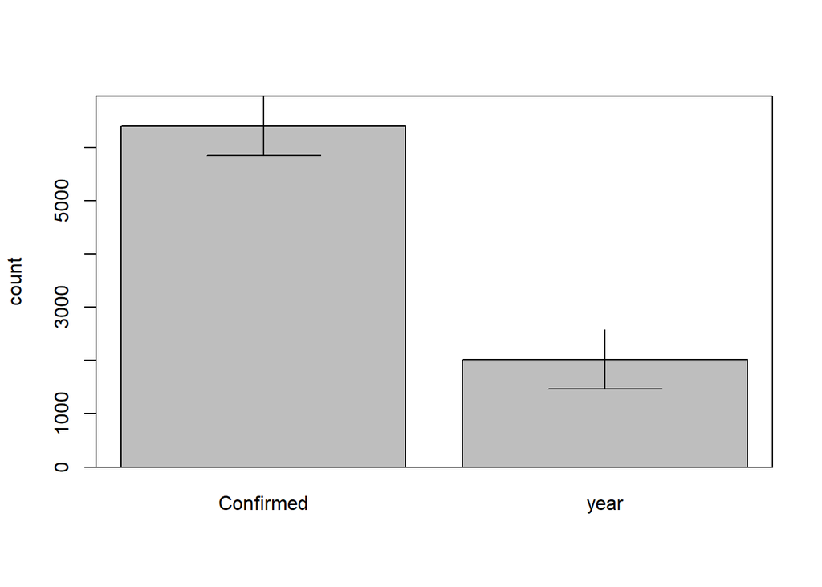

```r
segments(plot , meandata + df, plot , meandata - df)
segments(plot - 0.2, meandata - df, plot + 0.2, meandata - df)
box()
title(ylab = "count")
```

Creating mathematical expressions

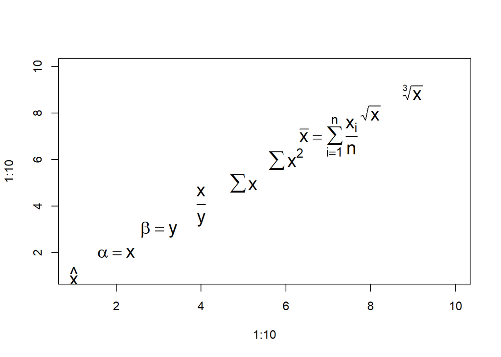

```r
plot(1:10 , 1:10, type = 'n')
opt = par(cex = 1.5)
text(1 , 1, expression(hat(x)))
text(2 , 2, expression(alpha == x))
text(3 , 3, expression(beta == y))
text(4 , 4, expression(frac(x, y)))
text(5 , 5, expression(sum(x)))
text(6 , 6, expression(sum(x^2)))
text(7 , 7, expression(bar(x) == sum(frac(x[i], n), i==1, n)))
text(8 , 8, expression(sqrt(x)))
text(9 , 9, expression(sqrt(x , 3)))
```

aggregate() function splits the data into subsets and computes summary statistics for each subsets and returns the result in agroup by form

```r
aggregate(data[ , 2:3], by = list(data$Confirmed), FUN = mean)
```

```
##     Group.1 Confirmed   year
## 1         0         0 2020.0
## 2         1         1 2020.0
## 3         2         2 2020.0
## 4         3         3 2020.0
## 5         4         4 2020.0
## 6         5         5 2020.0
## 7         6         6 2020.0
## 8         7         7 2020.0
## 9         8         8 2020.0
## 10        9         9 2020.0
## 11       10        10 2020.0
## 12       11        11 2020.0
## 13       12        12 2020.0
## 14       13        13 2020.0
```

[output cut: 445 more lines]

```r
aggregate(data$Confirmed ~ data$month, FUN = mean)
```

```
##    data$month data$Confirmed
## 1           1       5257.656
## 2           2       2284.684
## 3           3       1055.145
## 4           4       7447.583
## 5           5      15422.065
## 6           6       6679.150
## 7           7       7834.952
## 8           8       5664.625
## 9           9       4024.033
## 10         10       7645.129
## 11         11       5662.567
## 12         12       5095.194
```

```r
aggregate(data$Confirmed ~ data$month * data$year, FUN = mean)
```

```
##    data$month data$year data$Confirmed
## 1           1      2020   0.000000e+00
## 2           2      2020   6.896552e-02
## 3           3      2020   7.677419e+00
## 4           4      2020   8.533333e+00
## 5           5      2020   2.490323e+01
## 6           6      2020   1.057667e+02
## 7           7      2020   6.184194e+02
## 8           8      2020   1.670065e+03
## 9           9      2020   4.024033e+03
## 10         10      2020   7.645129e+03
## 11         11      2020   5.662567e+03
## 12         12      2020   5.095194e+03
## 13          1      2021   5.427258e+03
## 14          2      2021   4.650893e+03
## 15          3      2021   2.102613e+03
## 16          4      2021   1.488663e+04
## 17          5      2021   3.081923e+04
## 18          6      2021   1.325253e+04
## 19          7      2021   1.505148e+04
## 20          8      2021   1.942367e+04
```

```r
aggregate(cbind(data$Confirmed, data$month), by = list(data$year), FUN = mean)
```

```
##   Group.1        V1       V2
## 1    2020  2264.679 7.005952
## 2    2021 12690.638 4.180995
```